# Dissertation details

Last updated 8/19/2025

Shannon’s defense will take took place **9-11 AM (EST, UTC-5) Thursday, August 14th, 2025**. The defense was successful and resulted in the awarding of a PhD.

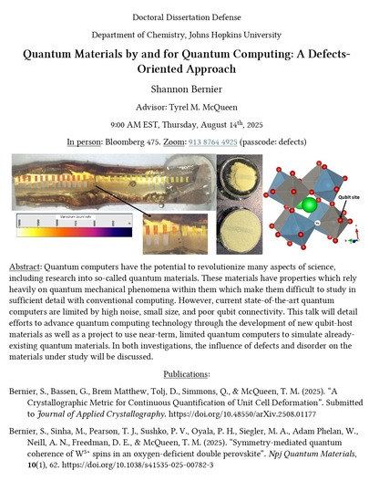

### Location

**In person in Bloomberg 475**, Johns Hopkins University, Baltimore, MD.

**Online or call-in at Zoom link**: now closed.

Please see [this page](https://support.zoom.com/hc/en/article?id=zm_kb&sysparm_article=KB0060732) for details on how to attend a Zoom meeting via telephone or internet-enabled device.

Participants were asked to leave this meeting once the public portion ended.

#### Celebration

Following the defense, there was a brief toast at the **3rd floor common area, Bloomberg Center for Physics & Astronomy**, Johns Hopkins University, Baltimore, MD and online over zoom **at approximately 10:45 AM August 14th**.

### What is a defense like?

There are two parts to a defense: the public and the private. The **public part** may be attended by anyone. During this part, the candidate (that’s Shannon) gives a talk detailing the contents of their thesis, or the work they’ve done over the course of their graduate program. The talk is designed for a scientific audience. After the talk, anyone is welcome to ask the candidate any question they like. The public part takes about 1 hour.

After the talk and public questions, everyone except the candidate and their examining committee are asked to leave the room. The candidate is then privately questioned by the committee, who decide if the candidate is ready and qualified to receive a PhD. This portion takes 1-2 hours.

Following this (and assuming a positive result), it is tradition to hold a short celebration toasting the candidate, who is now considered to have unofficially graduated with a doctoral degree. This celebration is also open to the public. It begins whenever the candidate finishes defending and ends when everyone goes home (usually 15 minutes to an hour after the start). There is sometimes food and usually champagne.

### What has Shannon’s PhD been about?

Shannon’s work has been at the intersection of chemistry, physics, and materials science, growing and studying crystals of what are called “quantum materials”. These materials have properties which can only be explained with a branch of physics called quantum mechanics. They have a range of applications; the ones relevant to Shannon’s work will be detailed at the thesis defense presentation along with how they were made and studied.

**Read the dissertation abstract**

*Many materials produced for studies in condensed matter physics are made using a limited set of “conventional” synthesis techniques and then characterized in a similar fashion. It is often assumed that samples prepared by different individuals, on different equipment, with different starting materials, and/or at different times are chemically identical provided their syntheses or diffraction patterns are similar. However, variations in other properties ranging from the subtle to the dramatic are commonly observed. More exhaustive characterization can reveal differences such as disorder, impurities, or changes in crystallographic orientation among samples, some of which can be the origin of these property changes. This is especially true for quantum materials, whose properties are contingent on the stabilization of a quantum mechanical state over a classical one which may be thermodynamically or entropically preferred under the vast majority of conditions.*

*Careful refinement of synthetic methods and a thorough approach towards characterization can help elucidate the properties of an “ideal” sample and guide materials refinement to produce desired properties. It also reveals the origins of differences between simulation and experiment, in turn providing useful information on how to improve theory tools.*

### What is Shannon doing after the defense?

Looking for a job and waiting to hear back from job applications, mostly. Shannon will be in-lab and around Baltimore through 8/22/2025.